# Activity Quality

Richelle V. Adams

Saturday, September 26, 2015

In this project, data from accelerometers on the belt, forearm, arm, and dumbell of 6 participants would be used to predict how well they performed barbell lifts. The outcome consists of five (5) different ways barbell lifts are performed correctly and incorrectly labelled as A, B, C, D, E.

The Weight Lifting Exercise dataset used for this project comes from http://groupware.les.inf.puc-rio.br/har. The file containing the data was pml-training.csv.

There were 19622 samples and 160 variables, one of which was the outcome called “classe”. It was the 160th variable. So there were 159 potential features. However, upon examining the data set, as seen below, there were a number of factor variables that had to be converted to numeric.

```
## 'data.frame':    19622 obs. of  160 variables:
##  $ X                       : int  1 2 3 4 5 6 7 8 9 10 ...
##  $ user_name               : Factor w/ 6 levels "adelmo","carlitos",..: 2 2 2 2 2 2 2 2 2 2 ...
##  $ raw_timestamp_part_1    : int  1323084231 1323084231 1323084231 1323084232 1323084232 1323084232 1323084232 1323084232 1323084232 1323084232 ...
##  $ raw_timestamp_part_2    : int  788290 808298 820366 120339 196328 304277 368296 440390 484323 484434 ...
##  $ cvtd_timestamp          : Factor w/ 20 levels "02/12/2011 13:32",..: 9 9 9 9 9 9 9 9 9 9 ...
##  $ new_window              : Factor w/ 2 levels "no","yes": 1 1 1 1 1 1 1 1 1 1 ...
##  $ num_window              : int  11 11 11 12 12 12 12 12 12 12 ...
##  $ roll_belt               : num  1.41 1.41 1.42 1.48 1.48 1.45 1.42 1.42 1.43 1.45 ...
##  $ pitch_belt              : num  8.07 8.07 8.07 8.05 8.07 8.06 8.09 8.13 8.16 8.17 ...
##  $ yaw_belt                : num  -94.4 -94.4 -94.4 -94.4 -94.4 -94.4 -94.4 -94.4 -94.4 -94.4 ...
##   [list output truncated]
```

The dataset was broken up randomly into a training set (75%) and test set (25%) for the purpose of cross-validation.

```r
inTrain<-createDataPartition(y=df$classe, p=0.75, list=FALSE)
training<-df[inTrain,]
testing<-df[-inTrain,]
```

```
##  [1] "X"                    "raw_timestamp_part_1" "raw_timestamp_part_2"
##  [4] "num_window"           "roll_belt"            "pitch_belt"
##  [7] "yaw_belt"             "total_accel_belt"     "gyros_belt_x"
## [10] "gyros_belt_y"         "gyros_belt_z"         "accel_belt_x"
## [13] "accel_belt_y"         "accel_belt_z"         "magnet_belt_x"
## [16] "magnet_belt_y"        "magnet_belt_z"        "roll_arm"
## [19] "pitch_arm"            "yaw_arm"              "total_accel_arm"
## [22] "gyros_arm_x"          "gyros_arm_y"          "gyros_arm_z"
## [25] "accel_arm_x"          "accel_arm_y"          "accel_arm_z"
## [28] "magnet_arm_x"         "magnet_arm_y"         "magnet_arm_z"
## [31] "roll_dumbbell"        "pitch_dumbbell"       "yaw_dumbbell"
## [34] "total_accel_dumbbell" "gyros_dumbbell_x"     "gyros_dumbbell_y"
## [37] "gyros_dumbbell_z"     "accel_dumbbell_x"     "accel_dumbbell_y"
## [40] "accel_dumbbell_z"     "magnet_dumbbell_x"    "magnet_dumbbell_y"
## [43] "magnet_dumbbell_z"    "roll_forearm"         "pitch_forearm"
## [46] "yaw_forearm"          "total_accel_forearm"  "gyros_forearm_x"
## [49] "gyros_forearm_y"      "gyros_forearm_z"      "accel_forearm_x"
## [52] "accel_forearm_y"      "accel_forearm_z"      "magnet_forearm_x"
## [55] "magnet_forearm_y"     "magnet_forearm_z"     "classe"
```

Additionally, the variables:raw_timestamp_part_1, raw_timestamp_part_2 and X were thought to be unnecessary for the prediction and were then also removed.

```r
training2<-select(training, one_of(anames))
training2<-select(training2, -raw_timestamp_part_1, -raw_timestamp_part_2, -X)

testing2<-select(testing, one_of(anames))
testing2<-select(testing2, -raw_timestamp_part_1, -raw_timestamp_part_2, -X)
```

Therefore, the number of features used in the prediction was 53.

For some exploratory data analysis a pair-wise scatter plot of the outcome “classe” and the variables “total_accel_dumbbell”, “total_accel_arm”, “total_accel_belt”, and “total_accel_forearm”. It can is shown as follows

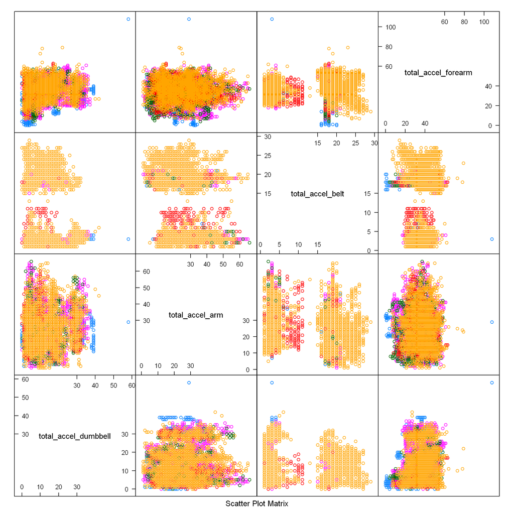

```r
featurePlot(x=training2[,c("total_accel_dumbbell", "total_accel_arm", "total_accel_belt", "total_accel_forearm")], y=training2$classe, plot="pairs")
```

It can be seen that the data set splits into two separate “portions” seemingly for all outcomes when the other three variables are plotted against “total_accel_belt” variable.

It was decided to determine if there were significant correlations (i.e., greater than 0.8) among the features (excluding the “classe” variable).

```
##                  row col
## yaw_belt           4   2
## total_accel_belt   5   2
## accel_belt_y      10   2
## accel_belt_z      11   2
## accel_belt_x       9   3
## magnet_belt_x     12   3
## roll_belt          2   4
## roll_belt          2   5
## accel_belt_y      10   5
## accel_belt_z      11   5
## pitch_belt         3   9
## magnet_belt_x     12   9
## roll_belt          2  10
## total_accel_belt   5  10
## accel_belt_z      11  10
## roll_belt          2  11
## total_accel_belt   5  11
## accel_belt_y      10  11
## pitch_belt         3  12
## accel_belt_x       9  12
## gyros_arm_y       20  19
## gyros_arm_x       19  20
## magnet_arm_x      25  22
## accel_arm_x       22  25
## magnet_arm_z      27  26
## magnet_arm_y      26  27
## accel_dumbbell_x  35  29
## accel_dumbbell_z  37  30
## gyros_dumbbell_z  34  32
## gyros_forearm_z   47  32
## gyros_dumbbell_x  32  34
## gyros_forearm_z   47  34
## pitch_dumbbell    29  35
## yaw_dumbbell      30  37
## gyros_forearm_z   47  46
## gyros_dumbbell_x  32  47
## gyros_dumbbell_z  34  47
## gyros_forearm_y   46  47
```

A significant number of pairs of variables have correlations greater than 0.8. Hence Principal Component Analysis (PCA) may be beneficial in improving the prediction model. Therefore we created the default prediction model - random forest - based on the training set with pca preprocessing.

```r
modelFit2<-train(classe ~., data=training2, preProcess="pca")
modelFit2
```

```
## Random Forest
##
## 14718 samples
##    53 predictor
##     5 classes: 'A', 'B', 'C', 'D', 'E'
##
## Pre-processing: principal component signal extraction, scaled, centered
## Resampling: Bootstrapped (25 reps)
## Summary of sample sizes: 14718, 14718, 14718, 14718, 14718, 14718, ...
## Resampling results across tuning parameters:
##
##   mtry  Accuracy   Kappa      Accuracy SD  Kappa SD
##    2    0.9681162  0.9596478  0.002939306  0.003732265
##   27    0.9506550  0.9375530  0.009016676  0.011388586
##   53    0.9505580  0.9374303  0.008841462  0.011169703
##
## Accuracy was used to select the optimal model using  the largest value.
## The final value used for the model was mtry = 2.
```

The model was then applied to the test set

```r
confusionMatrix(testing2$classe, predict(modelFit2,testing2))
```

```
## Confusion Matrix and Statistics
##
##           Reference
## Prediction    A    B    C    D    E
##          A 1384    6    1    2    2
##          B   12  926    9    0    2
##          C    3   11  835    6    0
##          D    2    1   39  758    4
##          E    0    2    3    0  896
##
## Overall Statistics
##
##                Accuracy : 0.9786
##                  95% CI : (0.9741, 0.9825)
##     No Information Rate : 0.2857
##     P-Value [Acc > NIR] : < 2.2e-16
##
##                   Kappa : 0.9729
##  Mcnemar's Test P-Value : 4.825e-05
##
## Statistics by Class:
##
##                      Class: A Class: B Class: C Class: D Class: E
## Sensitivity            0.9879   0.9789   0.9414   0.9896   0.9912
## Specificity            0.9969   0.9942   0.9950   0.9889   0.9988
## Pos Pred Value         0.9921   0.9758   0.9766   0.9428   0.9945
## Neg Pred Value         0.9952   0.9949   0.9872   0.9980   0.9980
## Prevalence             0.2857   0.1929   0.1809   0.1562   0.1843
## Detection Rate         0.2822   0.1888   0.1703   0.1546   0.1827
## Detection Prevalence   0.2845   0.1935   0.1743   0.1639   0.1837
## Balanced Accuracy      0.9924   0.9865   0.9682   0.9892   0.9950
```

Based on the model, it was found that the accuracy on the cross-validation testing set was 97.9% (See confusion matrix and statistics summary above). However, when the model was run on the testing data found in “pml-testing.csv”, 19 of the 20 symbols were predicted correctly - a 95% accuracy.